# Switchboard_Conversation

This R markdown notebook is intended to give a preview of the methods used for my dissertation analysis. For a more conceptual explanation of the analyses themselves, I have created some other R notebook tutorials, which you can read here: Calvino Engine (Recurrence Analysis) Fractal Fixation (Fractal Analysis)

The following analysis looks word level recurrence in one conversation, between Speaker A, and Speaker B.

Code can be ‘run’ (or just the results displayed) by going into a code chunk like the one below and pressing *Cmd+Shift+Enter*, or pressing the Run button (green arrow) at the top of the code section.

```r
library(data.table)
spkA <- fread("sw2001A-ms98-a-word.text")  #Read in the speaker transcripts
spkB <- fread("sw2001B-ms98-a-word.text")  #1)Speaker  2) Word onset 3)Word offset 4)Word
columns <- c("file","onset","offset","word")
colnames(spkA) <- columns
colnames(spkB) <- columns
wordsA <- spkA$word #Select just the words
wordsB <- spkB$word
```

Below is a quick look at what categorical Cross Recurrence Quantification Analysis does: make a matrix for every possible comparison between two series of items. In this case, wherever words are reused, the sparse matrix takes a value of TRUE, and these values of TRUE are then plotted.

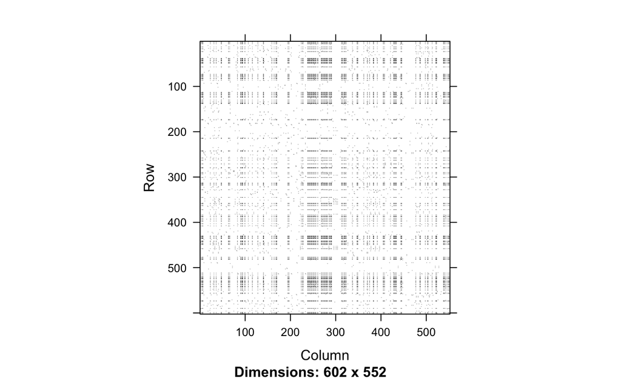

```r
library(Matrix)
library(pracma)
A_no <- 1:length(wordsA) #number of words from Speaker A
B_no <- 1:length(wordsB) #number of words from Speaker B
match_matrix <- spMatrix(length(wordsA),length(wordsB))  #create a matrix
for (i in A_no) {
  for (j in B_no) {
    match_matrix[i,j] <-strcmp(wordsA[i],wordsB[j]) }  #check for matches
  }
image(match_matrix)    #plot the matches vs misses.
```

Now we have a view of the matches throughout the conversation. The ratio of black/white within the plot, is giving us an overall indication of the amount of recurrence.